# BST 270 Final Project

Nick Birk

1/19/2024

# Introduction

The aim of the following project is to recreate one table and one figure from the FiveThirtyEight article:

[“Inside The Political Donation History Of Wealthy Sports Owners”](https://fivethirtyeight.com/features/inside-the-political-donation-history-of-wealthy-sports-owners/)

# Preparation

To proceed with the analysis, we will first need to load any necessary packages and import the dataset from online. If the dataset is available locally within the `data` folder, this option will instead be used to import the dataset. Note that the package `renv` is used to create an environment that saves the exact versions of each package used in the analysis. For completeness, the session info is also displayed at the end of this code chunk.

```r
# Begin by installing renv and setting up environment
if (!require('renv')) install.packages('renv')
renv::init()

# Install packages if they are missing, otherwise load
if (!require('tidyverse')) install.packages('tidyverse')
if (!require('ggplot2')) install.packages('ggplot2')
if (!require('RCurl')) install.packages('RCurl')
if (!require('knitr')) install.packages('knitr')

# Import dataset locally, if available
if (file.exists("../data/sports-political-donations.csv")){
    sports <- read.csv("../data/sports-political-donations.csv")
} else {
    # Otherwise, import dataset from raw github file online
   sports_url <- getURL("https://raw.githubusercontent.com/fivethirtyeight/data/master/sports-political-donations/sports-political-donations.csv")
   sports <- read.csv(text = sports_url)
}

# Display session information
```

[session information not shown]

# Part 1: Figure 1

To begin, we attempt to recreate the first figure that appears in the article, titled “Team owners give largely to the GOP”. To begin, we will observe the first few rows of the dataset to gain an understanding of what steps we will need to take to process the dataset.

```r
# Print first few rows of the dataset to understand features of the data
kable(head(sports))
```

| Owner | Team | League | Recipient | Amount | Election.Year | Party |
| --- | --- | --- | --- | --- | --- | --- |
| Adam Silver | Commissioner | NBA | WRIGHT 2016 | $4,000 | 2016 | Democrat |
| Adam Silver | Commissioner | NBA | BIDEN FOR PRESIDENT | $2,800 | 2020 | Democrat |
| Adam Silver | Commissioner | NBA | CORY 2020 | $2,700 | 2020 | Democrat |
| Adam Silver | Commissioner | NBA | Kamala Harris for the People | $2,700 | 2020 | Democrat |
| Adam Silver | Commissioner | NBA | Win The Era PAC | $2,700 | 2020 | Democrat |
| Adam Silver | Commissioner | NBA | KOHL FOR CONGRESS | $2,000 | 2018 | Democrat |

From an inspection of the data, one can see that some processing is required to obtain the values needed to reproduce the figure. In particular, we will first need to process the `Amount` column from a string (removing symbols such as $ and ,) to a numeric value.

```r
# Process the donation amount by removing $ and , symbols
sports$donate_amount <- str_replace(sports$Amount, "\\$", "")
sports$donate_amount <- str_replace(sports$donate_amount, "\\,", "")
# Second call needed for amounts which originally included two "," symbols
sports$donate_amount <- str_replace(sports$donate_amount, "\\,", "")
# Convert from character to numeric
sports$donate_amount <- as.numeric(sports$donate_amount)
# Confirm that this did not produce any NAs
print(sum(is.na(sports$donate_amount)))
```

```
## [1] 0
```

Now that the donation amount has been made numeric (as the column `donate_amount`), we can proceed. To reproduce the figure, we will want to create a summary of amount donated within each election year and party. We will use the `group_by` function to get the total donations for each party-election year pair. We will then display the table to ensure we have the correct categories.

```r
# Need to summarize by party, year to get figure values
sports_summary <- sports %>% group_by(Election.Year, Party) %>%
  summarize(total_donated = sum(donate_amount))

# We can see from inspecting this summary table that there are some extra categories which do not appear in the figure
kable(sports_summary)
```

| Election.Year | Party | total_donated |
| --- | --- | --- |
| 2016 | Bipartisan | 578050 |
| 2016 | Bipartisan, but mostly Democratic | 2000 |
| 2016 | Bipartisan, but mostly Republican | 83638 |
| 2016 | Democrat | 4065094 |
| 2016 | Independent | 2700 |
| 2016 | N/A | 7700 |
| 2016 | Republican | 12940514 |
| 2018 | Bipartisan | 540083 |
| 2018 | Bipartisan, but mostly Democratic | 6000 |
| 2018 | Bipartisan, but mostly Republican | 99103 |
| 2018 | Democrat | 4174212 |
| 2018 | Independent | 10800 |
| 2018 | N/A | 820000 |
| 2018 | Republican | 11282570 |
| 2020 | Bipartisan | 356566 |
| 2020 | Bipartisan, but mostly Democratic | 2800 |
| 2020 | Bipartisan, but mostly Republican | 88352 |
| 2020 | Democrat | 1874333 |
| 2020 | N/A | 21250 |
| 2020 | Republican | 10022932 |

We can see from the above that there are some extra political parties that do not appear in the figure itself. Further, it may be helpful to take an additional step to obtain the proportions of donations for the given year, rather than the raw amount, since the figure proportions do not add up to 100% because of the excluded parties. We make these final processing steps below and display the resulting table:

```r
# Create an even smaller summary dataset that includes the proportion
# Calculated as row amount / annual total

# First, annual total across all parties is stored in a small table
sports_annual_totals <- sports_summary %>% group_by(Election.Year) %>%
  summarize(annual_total = sum(total_donated))
# Join these values as new annual total column and then create proportion column
sports_summary <- inner_join(sports_summary, sports_annual_totals)
sports_summary <- sports_summary %>% mutate(donate_prop = total_donated/annual_total) %>% filter(Party %in% c("Republican", "Democrat"))

# Display table for visual inspection
kable(sports_summary)
```

| Election.Year | Party | total_donated | annual_total | donate_prop |
| --- | --- | --- | --- | --- |
| 2016 | Democrat | 4065094 | 17679696 | 0.2299301 |
| 2016 | Republican | 12940514 | 17679696 | 0.7319421 |
| 2018 | Democrat | 4174212 | 16932768 | 0.2465168 |
| 2018 | Republican | 11282570 | 16932768 | 0.6663157 |
| 2020 | Democrat | 1874333 | 12366233 | 0.1515686 |
| 2020 | Republican | 10022932 | 12366233 | 0.8105081 |

Finally, we see that we have the values needed to recreate the figure, and proceed to do so:

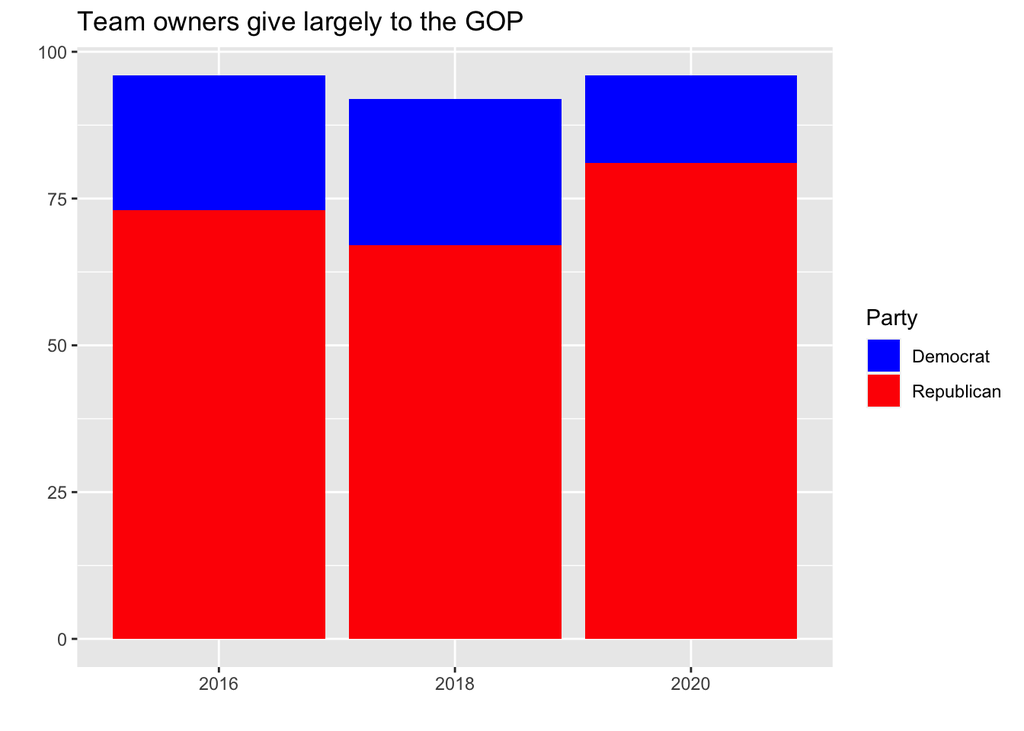

```r
# Plot figure 1
# Election Year is made a factor and donate_prop into a value between 0 and 100 for purely aesthetic reasons
sports_summary %>%
  ggplot(aes(as.factor(Election.Year), round(100*donate_prop), fill = Party)) + geom_bar(stat = "identity") +
  xlab("") + ylab("") + ggtitle("Team owners give largely to the GOP") +
  scale_fill_manual(values = c("blue", "red"))
```

On a visual basis, the values in the plot seem to roughly correspond to the values of each bar in the original article. For completeness, we can also attempt to reproduce the value from the figure caption, stating that “Giants owner Charles Johnson’s total contributions make up 32.1% of all Republican contributions”

```r
# Get the total sum of Republican donations across all years
republican_summary <- sports_summary %>% filter(Party == "Republican")
republican_total <- sum(republican_summary$total_donated)

# Get the total sum of Johnson's donations to Republicans across all years
johnson_summary <- sports %>% filter(Owner == "Charles Johnson", Party == "Republican")
johnson_total <- sum(johnson_summary$donate_amount)

# Print the proportion as a percentage, rounded to 1 decimal place.
print(round(100*johnson_total/republican_total, 1))
```

```
## [1] 32.1
```

Indeed, the computed percentage matches the reported amount exactly.

# Part 2: Table 2

We now attempt to reproduce the second table that appears in the article, titled “MLB owners have donated the most”.

To begin, we will need to summarize the total donations by league and party, rather than year.

```r
# We will reuse the donate_amount variable that we created previously
# Similar summary table needed as before, but split by league and party instead of year and party
sports_summary2 <- sports %>% group_by(League, Party) %>%
  summarize(total_donated = sum(donate_amount))

# Display the resulting table
kable(sports_summary2)
```

| League | Party | total_donated |
| --- | --- | --- |
| MLB | Bipartisan | 386833 |
| MLB | Bipartisan, but mostly Republican | 35500 |
| MLB | Democrat | 4466729 |
| MLB | N/A | 13950 |
| MLB | Republican | 14582661 |
| MLB, NASCAR | Republican | 2700 |
| MLB, NHL | Bipartisan | 20000 |
| MLB, NHL | Republican | 32500 |
| MLB, WNBA | Bipartisan | 25000 |
| MLB, WNBA | Democrat | 289900 |
| NASCAR | Bipartisan | 50000 |
| NASCAR | Bipartisan, but mostly Republican | 11000 |
| NASCAR | Democrat | 93983 |
| NASCAR | Republican | 573410 |
| NBA | Bipartisan | 22000 |
| NBA | Bipartisan, but mostly Republican | 92500 |
| NBA | Democrat | 1154079 |
| NBA | Independent | 8100 |
| NBA | Republican | 5225100 |
| NBA, MLB | Bipartisan | 25000 |
| NBA, MLB | Bipartisan, but mostly Democratic | 2000 |
| NBA, MLB | Democrat | 427975 |
| NBA, MLB | Independent | 5400 |
| NBA, MLB | N/A | 800000 |
| NBA, MLB | Republican | 563900 |
| NBA, NFL | Bipartisan | 5000 |
| NBA, NFL | Democrat | 166100 |
| NBA, NFL | Republican | 251400 |
| NBA, NFL, NHL | Bipartisan | 15000 |
| NBA, NFL, NHL | Democrat | 100000 |
| NBA, NFL, NHL | Republican | 33400 |
| NBA, NHL | Bipartisan, but mostly Democratic | 2800 |
| NBA, NHL | Bipartisan, but mostly Republican | 5000 |
| NBA, NHL | Democrat | 273720 |
| NBA, NHL | Republican | 1884800 |
| NBA, NHL, WNBA | Democrat | 163513 |
| NBA, WNBA | Bipartisan | 39000 |
| NBA, WNBA | Bipartisan, but mostly Republican | 25000 |
| NBA, WNBA | Democrat | 356100 |
| NBA, WNBA | N/A | 15000 |
| NBA, WNBA | Republican | 365000 |
| NFL | Bipartisan | 665650 |
| NFL | Bipartisan, but mostly Republican | 12500 |
| NFL | Democrat | 607400 |
| NFL | N/A | 20000 |
| NFL | Republican | 4621270 |
| NHL | Bipartisan | 212466 |
| NHL | Bipartisan, but mostly Democratic | 6000 |
| NHL | Bipartisan, but mostly Republican | 7500 |
| NHL | Democrat | 1189500 |
| NHL | Republican | 5010016 |
| NHL, NFL | Bipartisan | 5000 |
| NHL, NFL | Republican | 126400 |
| WNBA | Bipartisan | 3750 |
| WNBA | Bipartisan, but mostly Republican | 82093 |
| WNBA | Democrat | 824640 |
| WNBA | Republican | 973459 |

This initial version of the table reveals that there are some categories which include multiple leagues, and that additional parties are included that do not appear in the article’s table. To recreate the table exactly from the article, we will need to use some indicator that a row contains a given league. This is made somewhat more challenging than a standard text matching due to the presence of both “NBA” and “WNBA” as distinct leagues, and that some categories can contain multiple leagues (and thus should be double- or triple-counted). For our understanding of how to proceed, the different values of “League” are displayed below:

```r
# Display the frequency table of League values
kable(table(sports_summary2$League))
```

| Var1 | Freq |
| --- | --- |
| MLB | 5 |
| MLB, NASCAR | 1 |
| MLB, NHL | 2 |
| MLB, WNBA | 2 |
| NASCAR | 4 |
| NBA | 5 |
| NBA, MLB | 6 |
| NBA, NFL | 3 |
| NBA, NFL, NHL | 3 |
| NBA, NHL | 4 |
| NBA, NHL, WNBA | 1 |
| NBA, WNBA | 5 |
| NFL | 5 |
| NHL | 5 |
| NHL, NFL | 2 |
| WNBA | 4 |

We can use these unique values to obtain the corresponding totals from our previous summary table as follows:

```r
# Create vectors of the party total donations for each of the leagues, based on text matching
# And combine into a single summary table
tab2_summary <- data.frame(
    League = c("MLB", "NASCAR", "NBA", "NFL", "NHL", "WNBA"),
    # Match each of the League combinations for Republican donations
    republican_league_totals = c(sum(sports_summary2$total_donated[sports_summary2$Party == "Republican" & sports_summary2$League %in% c("MLB", "MLB, NASCAR", "MLB, NHL", "MLB, WNBA", "NBA, MLB")]),
                              sum(sports_summary2$total_donated[sports_summary2$Party == "Republican" & sports_summary2$League %in% c("MLB, NASCAR", "NASCAR")]),
                              sum(sports_summary2$total_donated[sports_summary2$Party == "Republican" & sports_summary2$League %in% c("NBA", "NBA, MLB", "NBA, NFL", "NBA, NFL, NHL", "NBA, NHL", "NBA, NHL, WNBA", "NBA, WNBA")]),
                              sum(sports_summary2$total_donated[sports_summary2$Party == "Republican" & sports_summary2$League %in% c("NFL", "NHL, NFL", "NBA, NFL", "NBA, NFL, NHL")]),
                              sum(sports_summary2$total_donated[sports_summary2$Party == "Republican" & sports_summary2$League %in% c("NHL", "MLB, NHL", "NBA, NFL, NHL", "NBA, NHL", "NBA, NHL, WNBA", "NHL, NFL")]),
                              sum(sports_summary2$total_donated[sports_summary2$Party == "Republican" & sports_summary2$League %in% c("WNBA", "NBA, WNBA", "NBA, NHL, WNBA", "MLB, WNBA")])
                                ),
    # Repeat for Democrat donations
    democrat_league_totals = c(sum(sports_summary2$total_donated[sports_summary2$Party == "Democrat" & sports_summary2$League %in% c("MLB", "MLB, NASCAR", "MLB, NHL", "MLB, WNBA", "NBA, MLB")]),
                              sum(sports_summary2$total_donated[sports_summary2$Party == "Democrat" & sports_summary2$League %in% c("MLB, NASCAR", "NASCAR")]),
                              sum(sports_summary2$total_donated[sports_summary2$Party == "Democrat" & sports_summary2$League %in% c("NBA", "NBA, MLB", "NBA, NFL", "NBA, NFL, NHL", "NBA, NHL", "NBA, NHL, WNBA", "NBA, WNBA")]),
                              sum(sports_summary2$total_donated[sports_summary2$Party == "Democrat" & sports_summary2$League %in% c("NFL", "NHL, NFL", "NBA, NFL", "NBA, NFL, NHL")]),
                              sum(sports_summary2$total_donated[sports_summary2$Party == "Democrat" & sports_summary2$League %in% c("NHL", "MLB, NHL", "NBA, NFL, NHL", "NBA, NHL", "NBA, NHL, WNBA", "NHL, NFL")]),
                              sum(sports_summary2$total_donated[sports_summary2$Party == "Democrat" & sports_summary2$League %in% c("WNBA", "NBA, WNBA", "NBA, NHL, WNBA", "MLB, WNBA")])
                                )
)
kable(tab2_summary)
```

| League | republican_league_totals | democrat_league_totals |
| --- | --- | --- |
| MLB | 15181761 | 5184604 |
| NASCAR | 576110 | 93983 |
| NBA | 8323600 | 2641487 |
| NFL | 5032470 | 873500 |
| NHL | 7087116 | 1726733 |
| WNBA | 1338459 | 1634153 |

Finally, we can combine this information and compute the total column (by simply summming Republican and Democrat) to obtain the league total donation amounts. We also note that the table appears to be displayed in descending order of total amounts donated, so we follow the same convention.

```r
# Mutate to add new column which sums republican and democrat donations
tab2 <- tab2_summary %>% mutate(Total = republican_league_totals + democrat_league_totals)

# Update column names to reflect article
colnames(tab2) <- c("League", "To Republicans", "To Democrats", "Total")

# Reorder rows to match article
# This can be done manually as
#tab2 <- tab2[c(1, 3, 5, 4, 6, 2),]
# But can also assume that the table is sorted by the Total column in descending order
tab2 <- tab2 %>% arrange(desc(Total))

# Display final table
kable(tab2)
```

| League | To Republicans | To Democrats | Total |
| --- | --- | --- | --- |
| MLB | 15181761 | 5184604 | 20366365 |
| NBA | 8323600 | 2641487 | 10965087 |
| NHL | 7087116 | 1726733 | 8813849 |
| NFL | 5032470 | 873500 | 5905970 |
| WNBA | 1338459 | 1634153 | 2972612 |
| NASCAR | 576110 | 93983 | 670093 |

The values in the table appear to mostly match the original article, including the ordering of rows, with the exception of the Republican donation amount for the NBA (and thus, the Total for this row as well). The Republican amount displayed in the article is 8,372,300, while the amount we have computed is 8,323,600. We can check the summary table for any donation amounts less than this difference to see if this reveals any potential missed rows as the reason for the discrepancy:

```r
# filter summary table to include only rows from the summary table with donation amount less than the observed difference
tab2_check <- sports_summary2 %>% filter(total_donated <= 8372300 - 8323600)

# Display
kable(tab2_check)
```

| League | Party | total_donated |
| --- | --- | --- |
| MLB | Bipartisan, but mostly Republican | 35500 |
| MLB | N/A | 13950 |
| MLB, NASCAR | Republican | 2700 |
| MLB, NHL | Bipartisan | 20000 |
| MLB, NHL | Republican | 32500 |
| MLB, WNBA | Bipartisan | 25000 |
| NASCAR | Bipartisan, but mostly Republican | 11000 |
| NBA | Bipartisan | 22000 |
| NBA | Independent | 8100 |
| NBA, MLB | Bipartisan | 25000 |
| NBA, MLB | Bipartisan, but mostly Democratic | 2000 |
| NBA, MLB | Independent | 5400 |
| NBA, NFL | Bipartisan | 5000 |
| NBA, NFL, NHL | Bipartisan | 15000 |
| NBA, NFL, NHL | Republican | 33400 |
| NBA, NHL | Bipartisan, but mostly Democratic | 2800 |
| NBA, NHL | Bipartisan, but mostly Republican | 5000 |
| NBA, WNBA | Bipartisan | 39000 |
| NBA, WNBA | Bipartisan, but mostly Republican | 25000 |
| NBA, WNBA | N/A | 15000 |
| NFL | Bipartisan, but mostly Republican | 12500 |
| NFL | N/A | 20000 |
| NHL | Bipartisan, but mostly Democratic | 6000 |
| NHL | Bipartisan, but mostly Republican | 7500 |
| NHL, NFL | Bipartisan | 5000 |
| WNBA | Bipartisan | 3750 |

# Conclusion

I was able to replicate the main findings from both the figure and table, though the NBA donation amounts and some aesthetic differences remain. Some challenges to reproducibility include the fact that more parties are included in the dataset than are reported in the tables/figures from the paper. This in itself is not a problem, but required a slight amount of “guessing and checking” to match the amounts from the article. The additional party names are somewhat addressed in the article figure captions, but it was not immediately clear to me whether categories such as “Bipartisan, but mostly Republican” should be included or excluded from the Republican total amounts (and same for Democrat).

Further, a slight challenge in reproducing Table 2 was in the encoding of the Leagues as a string that included all leagues represented. While this could be helpful in some contexts, it could have been easier for the coding of Table 2 specifically to also have a series of 6 binary variables that specify whether the corresponding donor owns a team in a given league (though noting this would also be redundant information in the table, and may have indeed be why the original dataset does not include this information). It is not clear whether this was part of the reason for the observed discrepancy in the table, but the need to process this variable to reproduce the table may have contributed to the difference. Additionally, I did not find it immediately clear whether the “Total” column in Table 2 corresponded to the total across all parties, or just the sum of Republican and Democrat amounts (though a visual check of the numbers strongly suggested that the Total was indeed just the sum of Republican and Democrat amounts). Further investigation is needed to more clearly determine the reason for the discrepancy in the NBA Republican total generated between this report and the FiveThirtyEight article.

In total, the figure and table were almost entirely reproduced, and the slight discrepancy in one row of the table does not change any of the overall conclusions that would be drawn by a reader. In general, the dataset was mostly intuitive and allowed for easy replication of the table and figure, with only some relatively minor questions arising during the process.